# Lab11 - Airport Data Analysis, Weather Observations

tony sulfaro

3/20/2019

## Question 01

```r
klan_daily = read_csv("KLAN_daily_weather_1970_2016.csv")
```

## Question 02

Variable WT16 is data that looks like logical data (boolean, TRUE/FALSE). After consulting the documentation file the variable indicates the presence of rain at that time. Meaning Rain, freezing rain, drizzle, freezing drizzle.

Here is what some of the data look like.

```r
head(klan_daily$WT16)
```

```
## [1] FALSE FALSE FALSE FALSE FALSE FALSE
```

## Question 03

The dataset consists of 40 variables (columns) and 17167 entries (rows) within the klan_daily dataset.

## Question 04

```r
klan_daily %>% filter(season == "winter") %>% arrange(desc(TMAX))
```

```
## # A tibble: 4,242 x 40
##    STATION_NAME DATE        PRCP  SNWD  SNOW  ACMH  ACSH  PSUN  TSUN TAVG
##    <chr>        <date>     <dbl> <dbl> <dbl> <dbl> <dbl> <dbl> <dbl> <lgl>
##  1 LANSING CAP… 1999-02-11  0.14     0     0    NA    NA    NA    NA NA
##  2 LANSING CAP… 2001-12-05  0.02    NA    NA    NA    NA    NA    NA NA
##  3 LANSING CAP… 1982-12-02  0.1      0     0   100   100     0     0 NA
##  4 LANSING CAP… 1982-12-03  0.93     0     0   100   100     0     0 NA
##  5 LANSING CAP… 1998-12-03  0        0     0    NA    NA    NA    NA NA
##  6 LANSING CAP… 1970-12-01  0.02     0     0    70    90     9    48 NA
##  7 LANSING CAP… 1982-12-25  0.77     0     0    80    90    35   186 NA
##  8 LANSING CAP… 1998-12-06  0.94     0     0    NA    NA    NA    NA NA
##  9 LANSING CAP… 1971-12-15  1.17     0     0   100    90     4    24 NA
## 10 LANSING CAP… 1984-02-23  0        0     0     0     0    NA   656 NA
## # … with 4,232 more rows, and 30 more variables: TMAX <dbl>, TMIN <dbl>,
## #   AWND <lgl>, WSFG <dbl>, WT09 <lgl>, WT14 <lgl>, WT07 <lgl>,
## #   WT01 <lgl>, WT15 <lgl>, WT17 <lgl>, WT06 <lgl>, WT21 <lgl>,
## #   WT05 <lgl>, WT02 <lgl>, WT11 <lgl>, WT22 <lgl>, WT04 <lgl>,
## #   WT13 <lgl>, WT16 <lgl>, WT08 <lgl>, WT18 <lgl>, WT03 <lgl>,
## #   WT10 <lgl>, WT19 <lgl>, weekday <chr>, month <chr>, day <dbl>,
## #   year <dbl>, week <dbl>, season <chr>
```

## Question 05

```r
klan_daily$above_freezing = (klan_daily$TMAX>32)
```

## Question 06

```r
klan_daily %>% filter(above_freezing==FALSE) %>% group_by(year) %>% summarise(below_freezing_count = n()) %>% arrange(desc(below_freezing_count))
```

```
## # A tibble: 47 x 2
##     year below_freezing_count
##    <dbl>                <int>
##  1  1978                   80
##  2  2014                   80
##  3  1977                   74
##  4  1985                   74
##  5  1989                   70
##  6  2010                   70
##  7  2008                   69
##  8  1980                   67
##  9  1995                   67
## 10  2003                   67
## # … with 37 more rows
```

## Question 07

```r
klan_daily %>% group_by(year) %>% summarise(precipitation = sum(PRCP)) %>% arrange(desc(precipitation))
```

```
## # A tibble: 47 x 2
##     year precipitation
##    <dbl>         <dbl>
##  1  2013          41.5
##  2  1975          39.6
##  3  2011          38.9
##  4  2009          38.1
##  5  1990          37.7
##  6  2014          37.5
##  7  1972          37.4
##  8  1986          37.1
##  9  2006          37.0
## 10  2008          36.6
## # … with 37 more rows
```

## Question 08

```r
klan_daily %>% group_by(year, month) %>%
  summarise(most_sunshine = sum(TSUN), average_sunshine = mean(TSUN, na.rm = TRUE), percent_sun = mean(PSUN, na.rm = TRUE)) %>%
  arrange(desc(most_sunshine))
```

```
## # A tibble: 564 x 5
## # Groups:   year [47]
##     year month most_sunshine average_sunshine percent_sun
##    <dbl> <chr>         <dbl>            <dbl>       <dbl>
##  1  1988 Jun           23479             783.       NaN
##  2  1977 May           23046             743.        84.4
##  3  1976 Jul           21966             709.        78.8
##  4  1971 Jun           21840             728         79.4
##  5  1983 Jul           21588             696.        77.2
##  6  1971 Jul           21480             693.        77.1
##  7  1988 May           21304             687.       NaN
##  8  1977 Jul           21132             682.        75.9
##  9  1982 Jul           21108             681.        75.7
## 10  1974 Jul           21060             679.        75.7
## # … with 554 more rows
```

## Question 09

The daily percent of possible sunshine (PSUN) imo was the least useful to me because at the time it was a prediction of how much sun but we already have how much sun there actually was (TSUN) because those days already happened. It would be useful to compare predictions with results but for our use case it is not as useful when seeing how much sun was actually had.

## Question 10

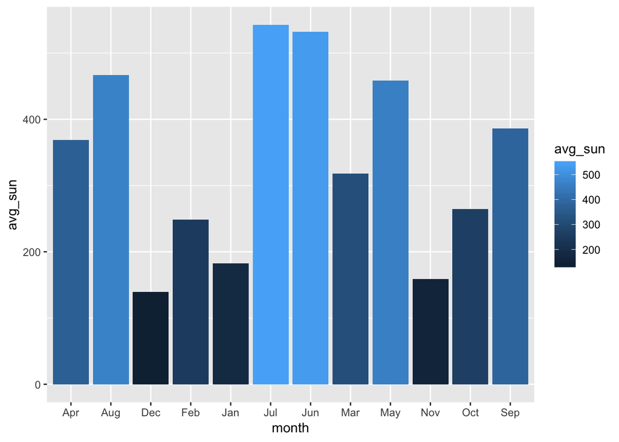

```r
klan_daily %>%
  group_by(month) %>%
  summarise(avg_sun = mean(TSUN, na.rm = TRUE)) %>%
  ggplot(aes(x=month, y =avg_sun)) + geom_bar(aes(fill = avg_sun),stat = "identity")
```

## Question 11

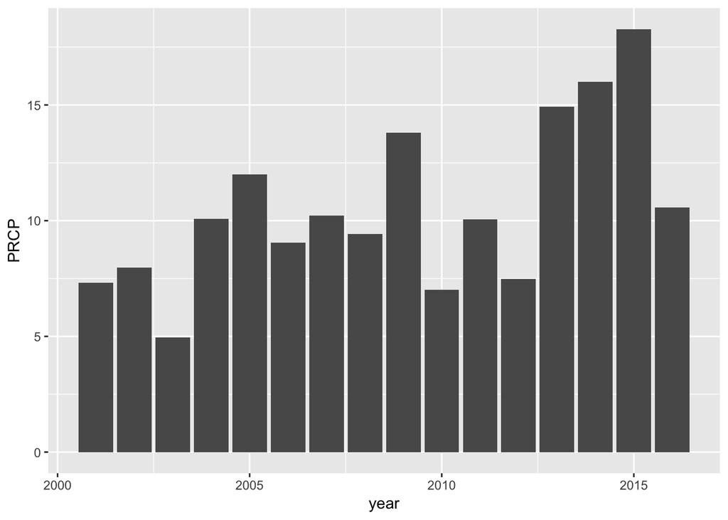

```r
klan_daily %>%
  filter(season=="summer" & year >= 2001 & year <= 2016) %>%
  group_by(year) %>%
  ggplot(aes(x=year, y=PRCP)) + geom_bar(stat = "identity")
```

## Question 12

```r
library(lubridate)
today()
```

```
## [1] "2019-03-24"
```

```r
now()
```

```
## [1] "2019-03-24 15:14:37 EDT"
```

## Question 13

Create date-time objects from

- “2017-02-22”
- “February 2nd, 2017”
- “02/21/2017 20:22:49”
- 20170218
- 02182017

```r
ymd("2017-02-22")
```

```
## [1] "2017-02-22"
```

```r
mdy("February   2nd, 2017")
```

```
## [1] "2017-02-02"
```

```r
mdy_hms("02/21/2017 20:22:49")
```

```
## [1] "2017-02-21 20:22:49 UTC"
```

```r
ymd(20170218)
```

```
## [1] "2017-02-18"
```

```r
mdy(02182017)
```

```
## [1] "2017-02-18"
```

## Question 14

```r
klan_daily$year = year(klan_daily$DATE)
klan_daily$month = month(klan_daily$DATE, label = TRUE, abbr = FALSE)
klan_daily$week = week(klan_daily$DATE)
klan_daily$day_of_week = wday(klan_daily$DATE, label = TRUE, abbr = FALSE)
klan_daily$day_of_month = mday(klan_daily$DATE)
klan_daily
```

```
## # A tibble: 17,167 x 43
##    STATION_NAME DATE        PRCP  SNWD  SNOW  ACMH  ACSH  PSUN  TSUN TAVG
##    <chr>        <date>     <dbl> <dbl> <dbl> <dbl> <dbl> <dbl> <dbl> <lgl>
##  1 LANSING CAP… 1970-01-01  0.1      1   2.4   100   100     5    30 NA
##  2 LANSING CAP… 1970-01-02  0.08     3   1.3   100   100     0     0 NA
##  3 LANSING CAP… 1970-01-03  0.02     4   0.4    90    90    34   186 NA
##  4 LANSING CAP… 1970-01-04  0.01     4   0.4    70    60    42   228 NA
##  5 LANSING CAP… 1970-01-05  0        4   0      30    60    62   342 NA
##  6 LANSING CAP… 1970-01-06  0        4   0.2    80    80    52   288 NA
##  7 LANSING CAP… 1970-01-07  0.03     4   0.7    90    60    35   192 NA
##  8 LANSING CAP… 1970-01-08  0.02     4   0.5    90    80    56   312 NA
##  9 LANSING CAP… 1970-01-09  0.01     4   0.2    60    70    59   330 NA
## 10 LANSING CAP… 1970-01-10  0.01     4   0.5    90   100    33   186 NA
## # … with 17,157 more rows, and 33 more variables: TMAX <dbl>, TMIN <dbl>,
## #   AWND <lgl>, WSFG <dbl>, WT09 <lgl>, WT14 <lgl>, WT07 <lgl>,
## #   WT01 <lgl>, WT15 <lgl>, WT17 <lgl>, WT06 <lgl>, WT21 <lgl>,
## #   WT05 <lgl>, WT02 <lgl>, WT11 <lgl>, WT22 <lgl>, WT04 <lgl>,
## #   WT13 <lgl>, WT16 <lgl>, WT08 <lgl>, WT18 <lgl>, WT03 <lgl>,
## #   WT10 <lgl>, WT19 <lgl>, weekday <chr>, month <ord>, day <dbl>,
## #   year <dbl>, week <dbl>, season <chr>, above_freezing <lgl>,
## #   day_of_week <ord>, day_of_month <int>
```

## Question 15

To find out if my results were correct I could look at specific dates on the calendar and compare to the timestamp to make sure everything lines up.

# Extra Credit

## Step 01

## Step 02